Return to Data Page

[figure not shown]

```python
import pandas as pd
import numpy as np
import datetime
from matplotlib import pyplot as plt
import seaborn as sns
import geopandas as gpd

from gapminder import gapminder
```

# $\color{darkblue}{\textbf{Import}}$

### $\color{dodgerblue}{\textbf{Creating New Data}}$

`pd.DataFrame()` on a dictionary creates a dataframe

```python
data_dict = {"Country": ["United States", "Canada", "Mexico"],
             "Captial": ["Washington D.C.", "Ottawa", "Ciudad de Mexico"],
             "Population_mil": [328.2, 37.59, 127.6]}

pd.DataFrame(data_dict)
```

```
         Country           Captial  Population_mil
0  United States   Washington D.C.          328.20
1         Canada            Ottawa           37.59
2         Mexico  Ciudad de Mexico          127.60
```

### $\color{dodgerblue}{\textbf{Importing}}$

#### $\color{skyblue}{\textrm{- CSV and Text Files}}$

`pandas` covers the basics like csv files with `pd.read_csv()`

```python
df = pd.read_csv("path/to/file.csv")

df = pd.read_csv("url")
```

If there are dates, use `parse_dates`

```python
df = pd.read_csv("path/to/file.csv", parse_dates = ["datecol1", "datecol2"])
```

#### $\color{skyblue}{\textrm{- Excel}}$

`pandas` can also deal with Excel files with the help of `xlrd`

```python
df = pd.ExcelFile("example.xlsx")
```

`sheet_names` returns the sheets in the file

```python
df.sheet_names
```

```
['lifeExp', 'pop', 'gdpPercap']
```

`parse()` pulls a specific sheet

```python
df.parse("lifeExp").head()
```

```
       country continent    1952    1957  ...    1992    1997    2002    2007
0  Afghanistan      Asia  28.801  30.332  ...  41.674  41.763  42.129  43.828
1      Albania    Europe  55.230  59.280  ...  71.581  72.950  75.651  76.423
2      Algeria    Africa  43.077  45.685  ...  67.744  69.152  70.994  72.301
3       Angola    Africa  30.015  31.999  ...  40.647  40.963  41.003  42.731
4    Argentina  Americas  62.485  64.399  ...  71.868  73.275  74.340  75.320

[5 rows x 14 columns]
```

#### $\color{skyblue}{\textrm{- Statistics Files}}$

`pandas` can read Stata files

```python
df = pd.read_stata("data.dta")
```

Separate pacakages are needed for other file types

```python
from sas7bdat import SAS7BDAT

with SAS7BDAT("data.sas7bdat") as file:
    df_sas = file.to_data_frame()
```

#### $\color{skyblue}{\textrm{- APIs}}$

```python
import requests #the module for making HTTP requests in Python; provides GET funcionality

try: #spelling depends on enviroment version
    import urllib2 as urllib #URL handling module
except ImportError:
    import urllib.request as urllib

import json
import glob #Unix style pathname pattern expansion
import sys
```

**NYC Open Data Example**

```python
parameter = {'pulocationid':149, 'dolocationid':132}
url =  "https://data.cityofnewyork.us/resource/t29m-gskq.json"
r = requests.get(url = url, params=parameter)
data = r.json()

data[1]
```

```
{'vendorid': '1',
 'tpep_pickup_datetime': '2018-02-26T05:07:58.000',
 'tpep_dropoff_datetime': '2018-02-26T05:31:54.000',
 'passenger_count': '1',
 'trip_distance': '15.90',
 'ratecodeid': '1',
 'store_and_fwd_flag': 'N',
 'pulocationid': '149',
 'dolocationid': '132',
 'payment_type': '1',
 'fare_amount': '43',
 'extra': '0.5',
 'mta_tax': '0.5',
 'tip_amount': '7',
 'tolls_amount': '0',
 'improvement_surcharge': '0.3',
 'total_amount': '51.3'}
```

```python
def getFare(df):

    fares = [] # list for storing fares

    for index, row in df.iterrows(): # iterating through all rows of sample points

        # specify parameters for making request
        parameters = {'pulocationid':int(row['Start_Zone']), 'dolocationid':int(row['End_Zone'])}

        url =  "https://data.cityofnewyork.us/resource/t29m-gskq.json"
        r = requests.get(url = url, params=parameters)
        data = r.json()

        odFare = []

        for obs in data: # iterating through each returned observation for the returned data

            # making sanity checks and appending fares to 'odFare' list
            try:
                fare = float(obs['fare_amount'])

                if (fare < 300 and fare > 2.5 ):
                    odFare.append(fare)

            except:
                pass

        # appending the mean of travel times retrieved above to the 'fares' list
        fares.append(np.mean(odFare))

    return fares
```

```python
data_dict = {"Trip": ["Home to JFK", "Home to LaGuardia"],
             "Start_Zone": [149, 149],
             "End_Zone": [132, 138]}

ods = pd.DataFrame(data_dict)

ods["Avg_Fare"] = getFare(ods)

ods
```

```
                Trip  Start_Zone  End_Zone  Avg_Fare
0        Home to JFK         149       132    42.875
1  Home to LaGuardia         149       138    62.125
```

#### $\color{skyblue}{\textrm{- Databases}}$

See the page on SQL for accessing data through relational databases.

### $\color{dodgerblue}{\textbf{Exporting}}$

`to_csv()` exports a dataframe as a csv file

```python
df.DataFrame.to_csv(index = False)
```

# $\color{darkblue}{\textbf{Clean}}$

### $\color{dodgerblue}{\textbf{Checking Data}}$

#### $\color{skyblue}{\textrm{- Contents}}$

`.head()` returns the first few rows

```python
gapminder.head()
```

```
       country continent  year  lifeExp       pop   gdpPercap
0  Afghanistan      Asia  1952   28.801   8425333  779.445314
1  Afghanistan      Asia  1957   30.332   9240934  820.853030
2  Afghanistan      Asia  1962   31.997  10267083  853.100710
3  Afghanistan      Asia  1967   34.020  11537966  836.197138
4  Afghanistan      Asia  1972   36.088  13079460  739.981106
```

`.info()` shows information on each of the columns, such as the data type and number of missing values

```python
gapminder.info()
```

```
<class 'pandas.core.frame.DataFrame'>
RangeIndex: 1704 entries, 0 to 1703
Data columns (total 6 columns):
 #   Column     Non-Null Count  Dtype
---  ------     --------------  -----
 0   country    1704 non-null   object
 1   continent  1704 non-null   object
 2   year       1704 non-null   int64
 3   lifeExp    1704 non-null   float64
 4   pop        1704 non-null   int64
 5   gdpPercap  1704 non-null   float64
dtypes: float64(2), int64(2), object(2)
memory usage: 80.0+ KB
```

`.shape` returns the number of rows and columns of the DataFrame

```python
gapminder.shape
```

```
(1704, 6)
```

`.columns` returns an index of column names

```python
gapminder.columns
```

```
Index(['country', 'continent', 'year', 'lifeExp', 'pop', 'gdpPercap'], dtype='object')
```

`.unique()` gives a list of all of the unique values in a specified column

```python
gapminder.continent.unique()
```

```
array(['Asia', 'Europe', 'Africa', 'Americas', 'Oceania'], dtype=object)
```

#### $\color{skyblue}{\textrm{- Validating}}$

Filters can be used to check the reasonableness of the range of values

```python
#Number of cases with unreasonable life expectancies
valid_life = (gapminder["lifeExp"] > 20) & (gapminder["lifeExp"] < 100)
len(gapminder) - len(gapminder[valid_life])
```

```
0
```

```python
#Number of cases with unreasonable populations
valid_pop = (gapminder["gdpPercap"] > 100) & (gapminder["pop"] < 1000000000000)
len(gapminder) - len(gapminder[valid_pop])
```

```
0
```

```python
#Filtering out unreasonable cases
gapminder = gapminder[valid_life & valid_pop]
```

#### $\color{skyblue}{\textrm{- Summarizing}}$

`.describe()` calculates a few summary statistics for each column

```python
gapminder.describe()
```

```
             year      lifeExp           pop      gdpPercap
count  1704.00000  1704.000000  1.704000e+03    1704.000000
mean   1979.50000    59.474439  2.960121e+07    7215.327081
std      17.26533    12.917107  1.061579e+08    9857.454543
min    1952.00000    23.599000  6.001100e+04     241.165876
25%    1965.75000    48.198000  2.793664e+06    1202.060309
50%    1979.50000    60.712500  7.023596e+06    3531.846988
75%    1993.25000    70.845500  1.958522e+07    9325.462346
max    2007.00000    82.603000  1.318683e+09  113523.132900
```

`.value_counts()` counts categorical variables, with the argument `noramlize = True` providing the relative frequency

```python
gapminder[gapminder["year"] == 2007]["continent"].value_counts()
```

```
Africa      52
Asia        33
Europe      30
Americas    25
Oceania      2
Name: continent, dtype: int64
```

```python
gapminder[gapminder["year"] == 2007]["continent"].value_counts(normalize = True)
```

```
Africa      0.366197
Asia        0.232394
Europe      0.211268
Americas    0.176056
Oceania     0.014085
Name: continent, dtype: float64
```

`.pivot_table()` can be used to make crosstabs

```python
conditions = [(gapminder["pop"].lt(4508000)),
             (gapminder["pop"].ge(4508000) & gapminder["pop"].le(31210000)),
             (gapminder["pop"].gt(31210000))]

choices = ["small", "average", "large"]

gapminder["size"] = np.select(conditions, choices)


gapminder[gapminder["year"] == 2007].pivot_table(values = "lifeExp",
                                                 index = "continent",
                                                 columns = "size",
                                                 aggfunc = len,
                                                 fill_value = 0,
                                                 margins = True)
```

```
size       average  large  small    All
continent
Africa          25     10     17   52.0
Americas        13      6      6   25.0
Asia            14     13      6   33.0
Europe          17      7      6   30.0
Oceania          1      0      1    2.0
All             70     36     36  142.0
```

`.groupby()` provides summary statistics for grouped data

```python
gapminder[gapminder["year"] > 1990].groupby(["continent", "year"]).agg({'country':'count',
                                                                        'pop':'sum',
                                                                        'lifeExp':'mean',
                                                                        'gdpPercap': 'median'})
```

```
                country         pop    lifeExp     gdpPercap
continent year
Africa    1992       52   659081517  53.629577   1161.631357
          1997       52   743832984  53.598269   1179.883114
          2002       52   833723916  53.325231   1215.683217
          2007       52   929539692  54.806038   1452.267078
Americas  1992       25   739274104  69.568360   6618.743050
          1997       25   796900410  71.150480   7113.692252
          2002       25   849772762  72.422040   6994.774861
          2007       25   898871184  73.608120   8948.102923
Asia      1992       33  3133292191  66.537212   3726.063507
          1997       33  3383285500  68.020515   3645.379572
          2002       33  3601802203  69.233879   4090.925331
          2007       33  3811953827  70.728485   4471.061906
Europe    1992       30   558142797  74.440100  17550.155945
          1997       30   568944148  75.505167  19596.498550
          2002       30   578223869  76.700600  23674.863230
          2007       30   586098529  77.648600  28054.065790
Oceania   1992        2    20919651  76.945000  20894.045885
          1997        2    22241430  78.190000  24024.175170
          2002        2    23454829  79.740000  26938.778040
          2007        2    24549947  80.719500  29810.188275
```

`.corr()` generates a correlation table

```python
gapminder.corr()
```

```
               year   lifeExp       pop  gdpPercap
year       1.000000  0.435611  0.082308   0.227318
lifeExp    0.435611  1.000000  0.064955   0.583706
pop        0.082308  0.064955  1.000000  -0.025600
gdpPercap  0.227318  0.583706 -0.025600   1.000000
```

#### $\color{skyblue}{\textrm{- Missing Values}}$

`.isna().sum()` returns the number of missing observations per column

```python
gapminder.isna().sum()
```

```
country      0
continent    0
year         0
lifeExp      0
pop          0
gdpPercap    0
size         0
dtype: int64
```

`.dropna()` removes entire rows with missing values

```python
gapminder.dropna(inplace = True)
```

`subset =` will only drop if the missing values are in the specified column

```python
gapminder.dropna(subset = ['country'], inplace = True)
```

`.fillna()` replaces all missing values with the specified value

```python
#All at once
gapminder.fillna(0, inplace = True)
```

```python
#Specific column and value
gapminder["country"] = gapminder["country"].fillna("Missing")
```

#### $\color{skyblue}{\textrm{- Duplicates}}$

`.drop_duplicates()` will keep only the first instance of each value in the column(s) specified

```python
gapminder.drop_duplicates("continent")
```

```
        country continent  year  lifeExp       pop     gdpPercap     size
0   Afghanistan      Asia  1952   28.801   8425333    779.445314  average
12      Albania    Europe  1952   55.230   1282697   1601.056136    small
24      Algeria    Africa  1952   43.077   9279525   2449.008185  average
48    Argentina  Americas  1952   62.485  17876956   5911.315053  average
60    Australia   Oceania  1952   69.120   8691212  10039.595640  average
```

```python
gapminder.drop_duplicates(["continent", "year"]).head()
```

```
       country continent  year  lifeExp       pop   gdpPercap     size
0  Afghanistan      Asia  1952   28.801   8425333  779.445314  average
1  Afghanistan      Asia  1957   30.332   9240934  820.853030  average
2  Afghanistan      Asia  1962   31.997  10267083  853.100710  average
3  Afghanistan      Asia  1967   34.020  11537966  836.197138  average
4  Afghanistan      Asia  1972   36.088  13079460  739.981106  average
```

#### $\color{skyblue}{\textrm{- Outliers}}$

First start with a histogram using `plt.hist()`. (We can already see what may be two high outliers)

[output not shown]

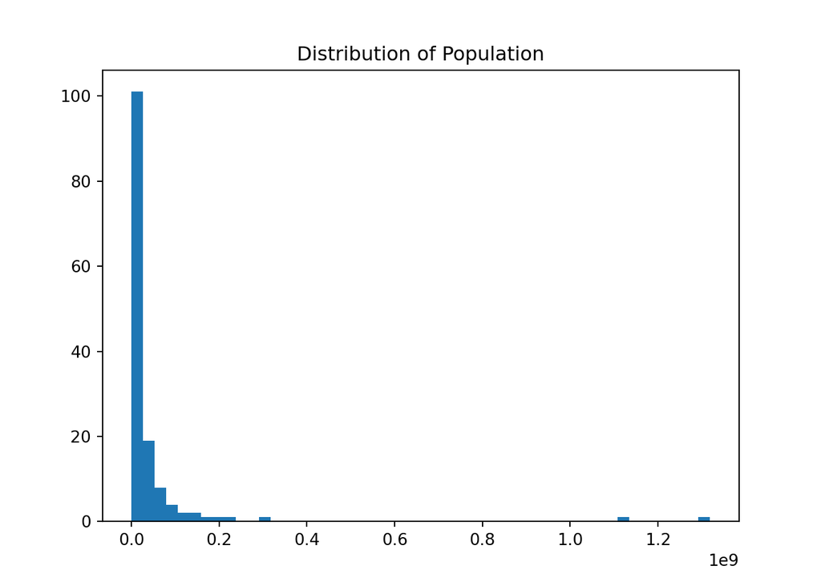

```python
gap_07 = gapminder[gapminder["year"] == 2007]

pop_hist = plt.hist(gap_07["pop"], bins = 50)
plt.title("Distribution of Population")
plt.show()
```

Transform into a log-scale histogram if needed.

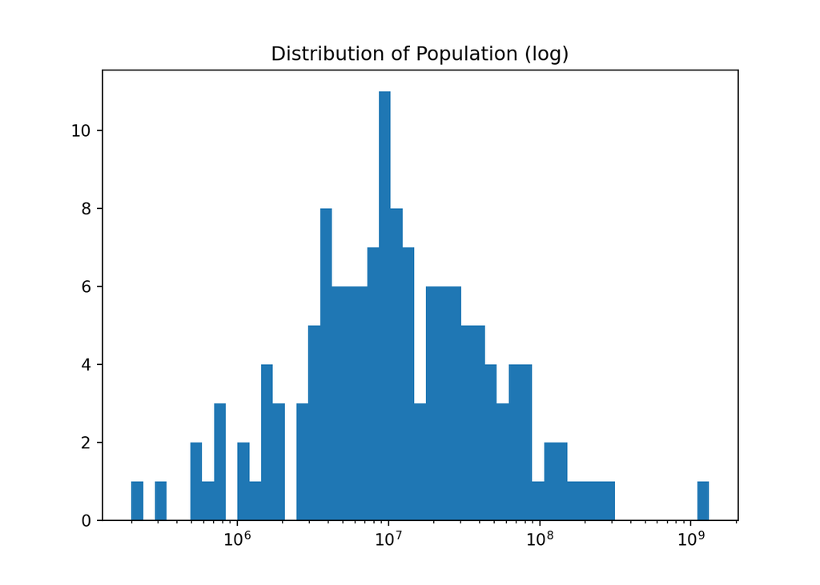

```python
def plot_loghist(x, bins):
  #function for plotting a log-scale histogram
  #it ensures log-scale binning and label on the original scale
    logbins = np.logspace(np.log10(x.min()),np.log10(x.max()),bins)
    plt.hist(x, bins=logbins)
    plt.xscale('log')

plot_loghist(gap_07["pop"], bins = 50)
plt.title("Distribution of Population (log)")
plt.show()
```

Next use `plt.boxplot()` to see the 25th, 75th, and median plotted with observations about a defined percentile plotted as circles. Here we see the two high points, but also the two lowest points.

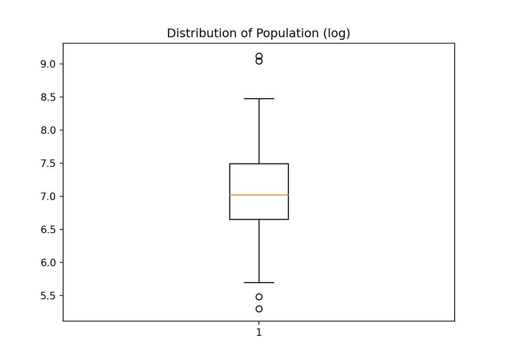

```python
pop_box = plt.boxplot(np.log10(gap_07["pop"]), whis=[1, 99]) #whiskers will by the 1% and 99%
plt.title("Distribution of Population (log)")
plt.show()
```

We can then pull these observations to validate (or drop)

```python
gap_07[gap_07["pop"] < gap_07["pop"].quantile(0.01)][["country", "continent", "pop"]]
```

```
                    country continent     pop
695                 Iceland    Europe  301931
1307  Sao Tome and Principe    Africa  199579
```

```python
gap_07[gap_07["pop"] > gap_07["pop"].quantile(0.99)][["country", "continent", "pop"]]
```

```
    country continent         pop
299   China      Asia  1318683096
707   India      Asia  1110396331
```

Alternatively, we can use a standard definition of “mean +/- 3 standard deviations” as a threshold for outliers.

```python
stdev = np.std(gap_07["pop"])
mean = np.mean(gap_07["pop"])
high_out = mean + (3 * stdev)
low_out = mean - (3 * stdev)

gap_07[(gap_07["pop"] < low_out) | (gap_07["pop"] > high_out)][["country", "continent", "pop"]]
```

```
    country continent         pop
299   China      Asia  1318683096
707   India      Asia  1110396331
```

We can now validate that we *were* expecting these and that they are correct, but in other cases we could drop them.

### $\color{dodgerblue}{\textbf{Wrangling}}$

#### $\color{skyblue}{\textrm{- Sorting}}$

`.sort_values()` sorts based on a column (ascending), the argument `ascending = False` returns descending sorting

```python
gapminder.sort_values(["country", "year"], ascending = [True, False]).head()
```

```
        country continent  year  lifeExp       pop   gdpPercap     size
11  Afghanistan      Asia  2007   43.828  31889923  974.580338    large
10  Afghanistan      Asia  2002   42.129  25268405  726.734055  average
9   Afghanistan      Asia  1997   41.763  22227415  635.341351  average
8   Afghanistan      Asia  1992   41.674  16317921  649.341395  average
7   Afghanistan      Asia  1987   40.822  13867957  852.395945  average
```

#### $\color{skyblue}{\textrm{- Subsetting}}$

```python
#Select Columns
gapminder[["country", "year", "lifeExp"]].head()
```

```
       country  year  lifeExp
0  Afghanistan  1952   28.801
1  Afghanistan  1957   30.332
2  Afghanistan  1962   31.997
3  Afghanistan  1967   34.020
4  Afghanistan  1972   36.088
```

```python
#Select Rows
gapminder.loc[[1, 3, 5]]
```

```
       country continent  year  lifeExp       pop   gdpPercap     size
1  Afghanistan      Asia  1957   30.332   9240934  820.853030  average
3  Afghanistan      Asia  1967   34.020  11537966  836.197138  average
5  Afghanistan      Asia  1977   38.438  14880372  786.113360  average
```

```python
#Select Columns and Rows
gapminder.loc[[1, 3, 5], ["country", "year", "lifeExp"]]
```

```
       country  year  lifeExp
1  Afghanistan  1957   30.332
3  Afghanistan  1967   34.020
5  Afghanistan  1977   38.438
```

#### $\color{skyblue}{\textrm{- Indexing}}$

`.set_index()` makes the selected column(s) into the index allowing for easier subsetting

```python
gapminder_ind = gapminder[gapminder["year"] > 2000].set_index("continent")

gapminder_ind.loc["Asia"].head()
```

```
               country  year  lifeExp        pop     gdpPercap     size
continent
Asia       Afghanistan  2002   42.129   25268405    726.734055  average
Asia       Afghanistan  2007   43.828   31889923    974.580338    large
Asia           Bahrain  2002   74.795     656397  23403.559270    small
Asia           Bahrain  2007   75.635     708573  29796.048340    small
Asia        Bangladesh  2002   62.013  135656790   1136.390430    large
```

```python
gapminder_ind = gapminder[gapminder["year"] > 2000].set_index(["continent", "country"])

gapminder_ind.loc[[("Asia", "Japan"),("Americas", "United States")]]
```

```
                         year  lifeExp        pop    gdpPercap   size
continent country
Asia      Japan          2002   82.000  127065841  28604.59190  large
          Japan          2007   82.603  127467972  31656.06806  large
Americas  United States  2002   77.310  287675526  39097.09955  large
          United States  2007   78.242  301139947  42951.65309  large
```

`.reset_index()` returns the index values to columns and renumbers the rows as an index

```python
gapminder_ind.loc[[("Asia", "Japan"),("Americas", "United States")]].reset_index()
```

```
  continent        country  year  lifeExp        pop    gdpPercap   size
0      Asia          Japan  2002   82.000  127065841  28604.59190  large
1      Asia          Japan  2007   82.603  127467972  31656.06806  large
2  Americas  United States  2002   77.310  287675526  39097.09955  large
3  Americas  United States  2007   78.242  301139947  42951.65309  large
```

#### $\color{skyblue}{\textrm{- Filtering}}$

Basic options include:

- `==`
- `!=`
- `>`
- `>=`
- `<`
- `<=`
- `() & ()`
- `() | ()`

```python
#Single Value
gapminder[gapminder["lifeExp"] > 82]
```

```
              country continent  year  lifeExp        pop    gdpPercap     size
671  Hong Kong, China      Asia  2007   82.208    6980412  39724.97867  average
803             Japan      Asia  2007   82.603  127467972  31656.06806    large
```

```python
#Multiple values with "and"
gapminder[(gapminder["lifeExp"] > 82) & (gapminder["pop"] > 10000000)]
```

```
    country continent  year  lifeExp        pop    gdpPercap   size
803   Japan      Asia  2007   82.603  127467972  31656.06806  large
```

```python
#Multiple values with "or"
gapminder[(gapminder["lifeExp"] > 82) | (gapminder["gdpPercap"] > 100000)]
```

```
              country continent  year  ...        pop     gdpPercap     size
671  Hong Kong, China      Asia  2007  ...    6980412   39724.97867  average
803             Japan      Asia  2007  ...  127467972   31656.06806    large
852            Kuwait      Asia  1952  ...     160000  108382.35290    small
853            Kuwait      Asia  1957  ...     212846  113523.13290    small
856            Kuwait      Asia  1972  ...     841934  109347.86700    small

[5 rows x 7 columns]
```

```python
#Multiple values in a list
gapminder[gapminder["continent"].isin(["Americas", "Oceania"])].head()
```

```
      country continent  year  lifeExp       pop    gdpPercap     size
48  Argentina  Americas  1952   62.485  17876956  5911.315053  average
49  Argentina  Americas  1957   64.399  19610538  6856.856212  average
50  Argentina  Americas  1962   65.142  21283783  7133.166023  average
51  Argentina  Americas  1967   65.634  22934225  8052.953021  average
52  Argentina  Americas  1972   67.065  24779799  9443.038526  average
```

```python
#Not equal to multiple values in a list
gapminder[gapminder["continent"].isin(["Americas", "Oceania"]) == False].head()
```

```
       country continent  year  lifeExp       pop   gdpPercap     size
0  Afghanistan      Asia  1952   28.801   8425333  779.445314  average
1  Afghanistan      Asia  1957   30.332   9240934  820.853030  average
2  Afghanistan      Asia  1962   31.997  10267083  853.100710  average
3  Afghanistan      Asia  1967   34.020  11537966  836.197138  average
4  Afghanistan      Asia  1972   36.088  13079460  739.981106  average
```

### $\color{dodgerblue}{\textbf{Mutating Columns}}$

#### $\color{skyblue}{\textrm{- New Columns}}$

```python
gapminder["gdp"] = gapminder["gdpPercap"] * gapminder["pop"]

gapminder.head()
```

```
       country continent  year  ...   gdpPercap     size           gdp
0  Afghanistan      Asia  1952  ...  779.445314  average  6.567086e+09
1  Afghanistan      Asia  1957  ...  820.853030  average  7.585449e+09
2  Afghanistan      Asia  1962  ...  853.100710  average  8.758856e+09
3  Afghanistan      Asia  1967  ...  836.197138  average  9.648014e+09
4  Afghanistan      Asia  1972  ...  739.981106  average  9.678553e+09

[5 rows x 8 columns]
```

#### $\color{skyblue}{\textrm{- Changing Type}}$

Use `.astype("str")` for strings

```python
gapminder['gdp'] = gapminder['gdp'].astype("str")

gapminder.head()
```

```
       country continent  year  ...   gdpPercap     size                gdp
0  Afghanistan      Asia  1952  ...  779.445314  average  6567086329.952229
1  Afghanistan      Asia  1957  ...  820.853030  average  7585448670.233646
2  Afghanistan      Asia  1962  ...  853.100710  average   8758855796.92893
3  Afghanistan      Asia  1967  ...  836.197138  average  9648014149.848902
4  Afghanistan      Asia  1972  ...  739.981106  average  9678553274.066868

[5 rows x 8 columns]
```

Use `pd.to_numeric()` for numeric

- `errors = 'ignore'` will return the original value
- `errors = 'coerce'` will return a null value

```python
gapminder['gdp'] = pd.to_numeric(gapminder['gdp'])

gapminder.head()
```

```
       country continent  year  ...   gdpPercap     size           gdp
0  Afghanistan      Asia  1952  ...  779.445314  average  6.567086e+09
1  Afghanistan      Asia  1957  ...  820.853030  average  7.585449e+09
2  Afghanistan      Asia  1962  ...  853.100710  average  8.758856e+09
3  Afghanistan      Asia  1967  ...  836.197138  average  9.648014e+09
4  Afghanistan      Asia  1972  ...  739.981106  average  9.678553e+09

[5 rows x 8 columns]
```

#### $\color{skyblue}{\textrm{- Cases}}$

`np.select()` with pre-defined conditions and choices operates like `case_when()`

```python
conditions = [(gapminder["pop"].lt(4508000)),
             (gapminder["pop"].ge(4508000) & gapminder["pop"].le(31210000)),
             (gapminder["pop"].gt(31210000))]

choices = ["small", "average", "large"]

gapminder["size"] = np.select(conditions, choices)

gapminder[gapminder["year"] == 2007].drop_duplicates("size")
```

```
        country continent  year  ...    gdpPercap     size           gdp
11  Afghanistan      Asia  2007  ...   974.580338    large  3.107929e+10
23      Albania    Europe  2007  ...  5937.029526    small  2.137641e+10
47       Angola    Africa  2007  ...  4797.231267  average  5.958390e+10

[3 rows x 8 columns]
```

### $\color{dodgerblue}{\textbf{Reshaping}}$

#### $\color{skyblue}{\textrm{- Spreading}}$

`.pivot()` spreads columns

```python
df = gapminder[["country", "continent", "year", "lifeExp"]].pivot(index = ["country", "continent"], columns = "year" , values = "lifeExp").reset_index()

df.columns.name = None

df.head()
```

```
       country continent    1952    1957  ...    1992    1997    2002    2007
0  Afghanistan      Asia  28.801  30.332  ...  41.674  41.763  42.129  43.828
1      Albania    Europe  55.230  59.280  ...  71.581  72.950  75.651  76.423
2      Algeria    Africa  43.077  45.685  ...  67.744  69.152  70.994  72.301
3       Angola    Africa  30.015  31.999  ...  40.647  40.963  41.003  42.731
4    Argentina  Americas  62.485  64.399  ...  71.868  73.275  74.340  75.320

[5 rows x 14 columns]
```

#### $\color{skyblue}{\textrm{- Gathering}}$

`melt()` gathers columns

```python
df.melt(id_vars=["country", "continent"], var_name = "year", value_name = "lifeExp").head()
```

```
       country continent  year  lifeExp
0  Afghanistan      Asia  1952   28.801
1      Albania    Europe  1952   55.230
2      Algeria    Africa  1952   43.077
3       Angola    Africa  1952   30.015
4    Argentina  Americas  1952   62.485
```

### $\color{dodgerblue}{\textbf{DateTimes}}$

#### $\color{skyblue}{\textrm{- Setting}}$

`pd.to_datetime()` formats a string as a datetime with the following formats:

| Directive | Meaning | Example |
| --- | --- | --- |
| %a | Abbreviated weekday | Sun, Mon, …, Sat |
| %A | Full weekday | Sunday, Monday, …, Saturday |
| %w | Weekday as a decimal number, where 0 is Sunday and 6 is Saturday | 0, 1, …, 6 |
| %d | Day of the month as a zero-padded decimal number | 01, 02, …, 31 |
| %b | Abbreviated month | Jan, Feb, …, Dec |
| %B | Full month | January, February, …, December |
| %m | Month as a zero-padded decimal number | 01, 02, …, 12 |
| %y | Year without century as a zero-padded decimal number | 00, 01, …, 99 |
| %Y | Year with century as a decimal number | 0001, 0002, …, 2013, 2014, …, 9998, 9999 |
| %H | Hour (24-hour clock) as a zero-padded decimal number | 00, 01, …, 23 |
| %I | Hour (12-hour clock) as a zero-padded decimal number | 01, 02, …, 12 |
| %p | AM or PM for %I hour | AM, PM |
| %M | Minute as a zero-padded decimal number | 00, 01, …, 59 |
| %S | Second as a zero-padded decimal number | 00, 01, …, 59 |
| %f | Microsecond as a decimal number, zero-padded to 6 digits | 000000, 000001, …, 999999 |
| %z | UTC offset in the form ±HHMM[SS[.ffffff]] (empty string if the object is naive) | (empty), +0000, -0400, +1030, +063415, -030712.345216 |
| %Z | Time zone name (empty string if the object is naive) | (empty), UTC, GMT |
| %j | Day of the year as a zero-padded decimal number | 001, 002, …, 366 |
| %U | Week number of the year (Sunday as the first day of the week) as a zero-padded decimal number; all days in a new year preceding the first Sunday are considered to be in week 0 | 00, 01, …, 53 |
| %W | Week number of the year (Monday as the first day of the week) as a zero-padded decimal number; all days in a new year preceding the first Monday are considered to be in week 0 | 00, 01, …, 53 |

```python
gapminder['date_year'] = pd.to_datetime(gapminder['year'], format = '%Y')

gapminder.head()
```

```
       country continent  year  ...     size           gdp  date_year
0  Afghanistan      Asia  1952  ...  average  6.567086e+09 1952-01-01
1  Afghanistan      Asia  1957  ...  average  7.585449e+09 1957-01-01
2  Afghanistan      Asia  1962  ...  average  8.758856e+09 1962-01-01
3  Afghanistan      Asia  1967  ...  average  9.648014e+09 1967-01-01
4  Afghanistan      Asia  1972  ...  average  9.678553e+09 1972-01-01

[5 rows x 9 columns]
```

#### $\color{skyblue}{\textrm{- Extracting}}$

`dt` has:

- `dt.year`
- `dt.month`
- `dt.day`
- `dt.hour`
- `dt.minute`

```python
gapminder["month"] = gapminder["date_year"].dt.month

gapminder.head()
```

```
       country continent  year  ...           gdp  date_year  month
0  Afghanistan      Asia  1952  ...  6.567086e+09 1952-01-01      1
1  Afghanistan      Asia  1957  ...  7.585449e+09 1957-01-01      1
2  Afghanistan      Asia  1962  ...  8.758856e+09 1962-01-01      1
3  Afghanistan      Asia  1967  ...  9.648014e+09 1967-01-01      1
4  Afghanistan      Asia  1972  ...  9.678553e+09 1972-01-01      1

[5 rows x 10 columns]
```

#### $\color{skyblue}{\textrm{- Comparing}}$

```python
gapminder[gapminder["date_year"] > pd.to_datetime("1990-07-04 12:01:00")].head()
```

```
        country continent  year  ...           gdp  date_year  month
8   Afghanistan      Asia  1992  ...  1.059590e+10 1992-01-01      1
9   Afghanistan      Asia  1997  ...  1.412200e+10 1997-01-01      1
10  Afghanistan      Asia  2002  ...  1.836341e+10 2002-01-01      1
11  Afghanistan      Asia  2007  ...  3.107929e+10 2007-01-01      1
20      Albania    Europe  1992  ...  8.307722e+09 1992-01-01      1

[5 rows x 10 columns]
```

Return to Data Page